# Background

The objective of this project is to develop a predictive model through random forest. The project aims to provide insights into which demographic features or pollutants contribute the most to air pollution, how effectively air quality categories are classified across classes, and the model's generalizability on unseen air quality conditions. Answering these questions can help public health officials and lawmakers deliver timely advisory warnings to at-risk populations and establish effective interventions aimed at the sources of air pollution.

## Dataset Info

**Features:**

1. Temperature (°C): Average temperature of the region.
2. Humidity (%): Relative humidity recorded in the region.
3. PM2.5 Concentration (µg/m³): Fine particulate matter levels.
4. PM10 Concentration (µg/m³): Coarse particulate matter levels.
5. NO2 Concentration (ppb): Nitrogen dioxide levels.
6. SO2 Concentration (ppb): Sulfur dioxide levels.
7. CO Concentration (ppm): Carbon monoxide levels.
8. Proximity to Industrial Areas (km): Distance to the nearest industrial zone.
9. Population Density (people/km²): Number of people per square kilometer in the region.

**Target Variable:** Air quality levels

- Good: Clean air with low pollution levels.
- Moderate: Acceptable air quality but with some pollutants present.
- Poor Noticeable pollution that may cause health issues for sensitive groups.
- Hazardous = 3 - Highly polluted air posing serious health risks to the population.

# Load & Explore Data

```python
# Import libraries

import pandas as pd
import numpy as np
import matplotlib.pyplot as plt
import seaborn as sns

from sklearn.model_selection import train_test_split, GridSearchCV
from sklearn.ensemble import RandomForestClassifier
from sklearn.preprocessing import StandardScaler
from sklearn.pipeline import Pipeline
from sklearn.metrics import confusion_matrix, accuracy_score, classification_report, precision_score, recall_score, f1_score
```

```python
# Mount Google Drive

from google.colab import drive
drive.mount('/content/drive')
```

```python
# Load Air Quality & Pollution dataset

data = pd.read_csv('/content/drive/MyDrive/Math237Fall25/Datasets/updated_pollution_dataset.csv')
data.head()
```

|  | Temperature | Humidity | PM2.5 | PM10 | NO2 | SO2 | CO | Proximity_to_Industrial_Areas | Population_Density | Air Quality |
| --- | --- | --- | --- | --- | --- | --- | --- | --- | --- | --- |
| 0 | 29.8 | 59.1 | 5.2 | 17.9 | 18.9 | 9.2 | 1.72 | 6.3 | 319 | Moderate |
| 1 | 28.3 | 75.6 | 2.3 | 12.2 | 30.8 | 9.7 | 1.64 | 6.0 | 611 | Moderate |
| 2 | 23.1 | 74.7 | 26.7 | 33.8 | 24.4 | 12.6 | 1.63 | 5.2 | 619 | Moderate |
| 3 | 27.1 | 39.1 | 6.1 | 6.3 | 13.5 | 5.3 | 1.15 | 11.1 | 551 | Good |
| 4 | 26.5 | 70.7 | 6.9 | 16.0 | 21.9 | 5.6 | 1.01 | 12.7 | 303 | Good |

```python
# Quick look at data

data.info()
data.shape
```

```
<class 'pandas.core.frame.DataFrame'>
RangeIndex: 5000 entries, 0 to 4999
Data columns (total 10 columns):
 #   Column                         Non-Null Count  Dtype
---  ------                         --------------  -----
 0   Temperature                    5000 non-null   float64
 1   Humidity                       5000 non-null   float64
 2   PM2.5                          5000 non-null   float64
 3   PM10                           5000 non-null   float64
 4   NO2                            5000 non-null   float64
 5   SO2                            5000 non-null   float64
 6   CO                             5000 non-null   float64
 7   Proximity_to_Industrial_Areas  5000 non-null   float64
 8   Population_Density             5000 non-null   int64
 9   Air Quality                    5000 non-null   object
dtypes: float64(8), int64(1), object(1)
memory usage: 390.8+ KB
```

```
(5000, 10)
```

```python
# Check missing values

data.isnull().sum()
```

|  | 0 |
| --- | --- |
| Temperature | 0 |
| Humidity | 0 |
| PM2.5 | 0 |
| PM10 | 0 |
| NO2 | 0 |
| SO2 | 0 |
| CO | 0 |
| Proximity_to_Industrial_Areas | 0 |
| Population_Density | 0 |
| Air Quality | 0 |

**dtype:** int64

There are no missing values and the features are already in a numerical format. Only the target variables have to be tranformed to numerical.

# Data Cleaning

```python
# Value counts for target variable

display(data['Air Quality'].value_counts())
```

| Air Quality | count |
| --- | --- |
| Good | 2000 |
| Moderate | 1500 |
| Poor | 1000 |
| Hazardous | 500 |

**dtype:** int64

```python
# Transform Air Quality from categorical to numerical

data_clean = data.copy()
data_clean['Air Quality'] = data_clean['Air Quality'].map({'Good': 0, 'Moderate': 1, 'Poor': 2, 'Hazardous': 3})
data_clean.head()
```

|  | Temperature | Humidity | PM2.5 | PM10 | NO2 | SO2 | CO | Proximity_to_Industrial_Areas | Population_Density | Air Quality |
| --- | --- | --- | --- | --- | --- | --- | --- | --- | --- | --- |
| 0 | 29.8 | 59.1 | 5.2 | 17.9 | 18.9 | 9.2 | 1.72 | 6.3 | 319 | 1 |
| 1 | 28.3 | 75.6 | 2.3 | 12.2 | 30.8 | 9.7 | 1.64 | 6.0 | 611 | 1 |
| 2 | 23.1 | 74.7 | 26.7 | 33.8 | 24.4 | 12.6 | 1.63 | 5.2 | 619 | 1 |
| 3 | 27.1 | 39.1 | 6.1 | 6.3 | 13.5 | 5.3 | 1.15 | 11.1 | 551 | 0 |
| 4 | 26.5 | 70.7 | 6.9 | 16.0 | 21.9 | 5.6 | 1.01 | 12.7 | 303 | 0 |

```python
# Encoding check

display(data_clean['Air Quality'].value_counts())
```

| Air Quality | count |
| --- | --- |
| 0 | 2000 |
| 1 | 1500 |
| 2 | 1000 |
| 3 | 500 |

**dtype:** int64

# Exploratory Data Analysis

```python
# Display basic statistics

data_clean.describe()
```

|  | Temperature | Humidity | PM2.5 | PM10 | NO2 | SO2 | CO | Proximity_to_Industrial_Areas | Population_Density | Air Quality |
| --- | --- | --- | --- | --- | --- | --- | --- | --- | --- | --- |
| count | 5000.000000 | 5000.000000 | 5000.000000 | 5000.000000 | 5000.000000 | 5000.000000 | 5000.000000 | 5000.000000 | 5000.000000 | 5000.0000 |
| mean | 30.029020 | 70.056120 | 20.142140 | 30.218360 | 26.412100 | 10.014820 | 1.500354 | 8.425400 | 497.423800 | 1.0000 |
| std | 6.720661 | 15.863577 | 24.554546 | 27.349199 | 8.895356 | 6.750303 | 0.546027 | 3.610944 | 152.754084 | 1.0001 |
| min | 13.400000 | 36.000000 | 0.000000 | -0.200000 | 7.400000 | -6.200000 | 0.650000 | 2.500000 | 188.000000 | 0.0000 |
| 25% | 25.100000 | 58.300000 | 4.600000 | 12.300000 | 20.100000 | 5.100000 | 1.030000 | 5.400000 | 381.000000 | 0.0000 |
| 50% | 29.000000 | 69.800000 | 12.000000 | 21.700000 | 25.300000 | 8.000000 | 1.410000 | 7.900000 | 494.000000 | 1.0000 |
| 75% | 34.000000 | 80.300000 | 26.100000 | 38.100000 | 31.900000 | 13.725000 | 1.840000 | 11.100000 | 600.000000 | 2.0000 |
| max | 58.600000 | 128.100000 | 295.000000 | 315.800000 | 64.900000 | 44.900000 | 3.720000 | 25.800000 | 957.000000 | 3.0000 |

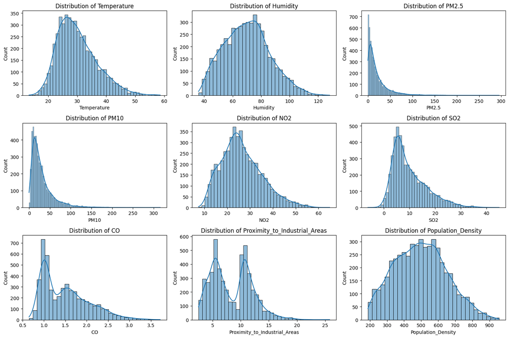

```python
# Visualize distribution of numerical features

plt.figure(figsize=(15, 10))
for i, col in enumerate(data_clean.columns[:-1]):
    plt.subplot(3, 3, i+1)
    sns.histplot(data_clean[col], kde=True)
    plt.title(f'Distribution of {col}')
plt.tight_layout()
plt.show()
```

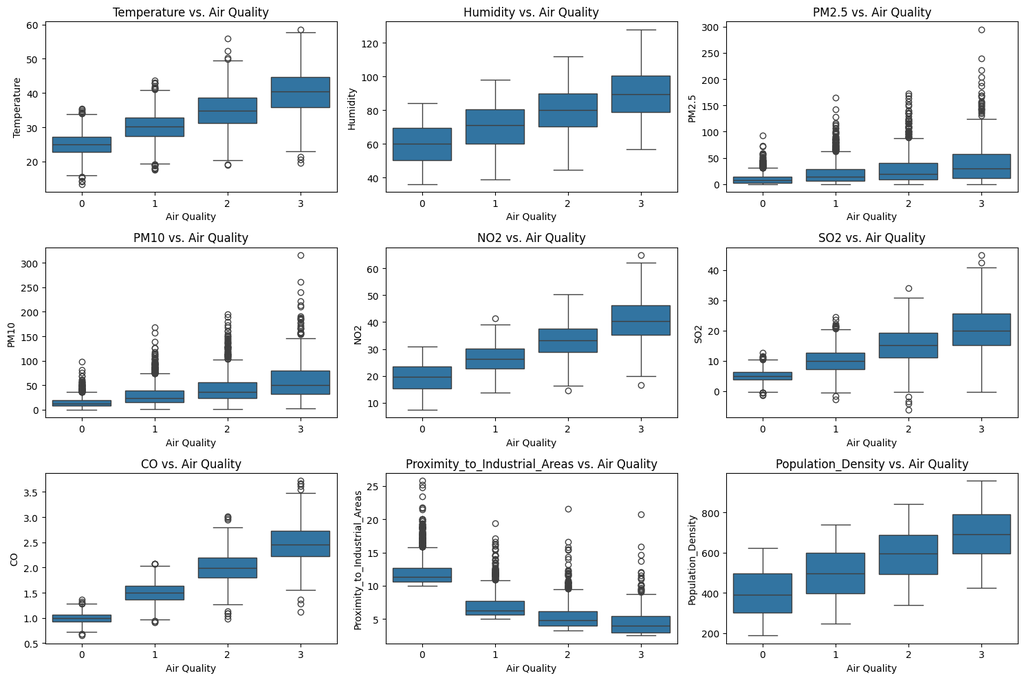

```python
# Boxplots of features vs. Air Quality (Good:0, Moderate:1, Poor:2, Hazardous:3)

plt.figure(figsize=(15, 10))
for i, col in enumerate(data_clean.columns[:-1]):
    plt.subplot(3, 3, i+1)
    sns.boxplot(x='Air Quality', y=col, data=data_clean)
    plt.title(f'{col} vs. Air Quality')
plt.tight_layout()
plt.show()
```

**Observations**:

- As Temperature, Humidity, PM2.5, PM10, NO2, SO2, CO, & Population_Density increase, Air Quality worsens
- When Proximity_to_Industrial_Areas increases, Air Quailty improves

```python
# Calculate correlation matrix

corr_matrix = data_clean.corr()
print(corr_matrix['Air Quality'].sort_values(key=abs, ascending=False))
```

```
Air Quality                      1.000000
CO                               0.912534
NO2                              0.785030
Proximity_to_Industrial_Areas   -0.773637
Temperature                      0.753567
SO2                              0.740201
Population_Density               0.645546
Humidity                         0.625546
PM10                             0.555691
PM2.5                            0.418171
Name: Air Quality, dtype: float64
```

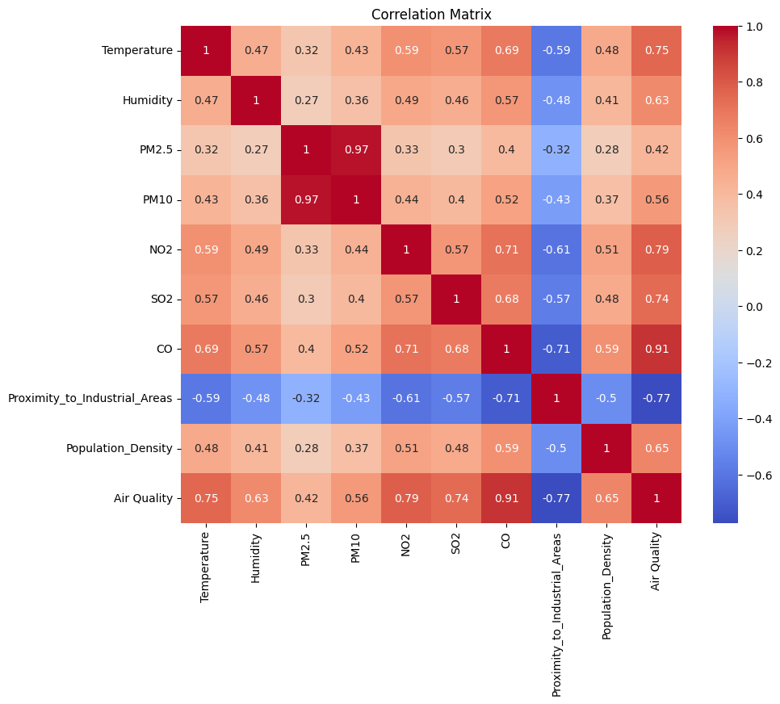

```python
# Visualize correlation matrix

plt.figure(figsize=(10, 8))
sns.heatmap(corr_matrix, annot=True, cmap='coolwarm')
plt.title('Correlation Matrix')
plt.show()
```

**Observations**:

- High multicollinearity between "PM2.5" and "PM10" (0.97)
- Remove "PM10" to improve model's stability and performance

```python
# Remove PM10 (highly correlated w/ PM2.5)

data_clean = data_clean.drop('PM10', axis=1)
data_clean.head()
```

|  | Temperature | Humidity | PM2.5 | NO2 | SO2 | CO | Proximity_to_Industrial_Areas | Population_Density | Air Quality |
| --- | --- | --- | --- | --- | --- | --- | --- | --- | --- |
| 0 | 29.8 | 59.1 | 5.2 | 18.9 | 9.2 | 1.72 | 6.3 | 319 | 1 |
| 1 | 28.3 | 75.6 | 2.3 | 30.8 | 9.7 | 1.64 | 6.0 | 611 | 1 |
| 2 | 23.1 | 74.7 | 26.7 | 24.4 | 12.6 | 1.63 | 5.2 | 619 | 1 |
| 3 | 27.1 | 39.1 | 6.1 | 13.5 | 5.3 | 1.15 | 11.1 | 551 | 0 |
| 4 | 26.5 | 70.7 | 6.9 | 21.9 | 5.6 | 1.01 | 12.7 | 303 | 0 |

# Prepare Data for Random Forest

```python
# Define features (X) & target (y)

X = data_clean.drop('Air Quality', axis=1)
y = data_clean['Air Quality']

print("Feature matrix X shape:", X.shape)
print("Target vector y shape:", y.shape)
```

```
Feature matrix X shape: (5000, 8)
Target vector y shape: (5000,)
```

```python
# Create three-way split
# First split: train + val (80%), test (20%)

X_temp, X_test, y_temp, y_test = train_test_split(X, y, test_size=0.2, random_state=42)

# Second split: 75% of temp = train (60%), 25% of temp = val (20%)

X_train, X_val, y_train, y_val = train_test_split(X_temp, y_temp, test_size=0.25, random_state=42)

print("Data split sizes:")
print(f"Training:   {len(X_train)} samples ({len(X_train)/len(X)*100:.1f}%)")
print(f"Validation: {len(X_val)} samples ({len(X_val)/len(X)*100:.1f}%)")
print(f"Test:       {len(X_test)} samples ({len(X_test)/len(X)*100:.1f}%)")
print(f"Total:      {len(X)} samples")
```

```
Data split sizes:
Training:   3000 samples (60.0%)
Validation: 1000 samples (20.0%)
Test:       1000 samples (20.0%)
Total:      5000 samples
```

```python
# Create pipeline (will act as the model)

pipeline = Pipeline([
    ('scaler', StandardScaler()),
    ('classifier', RandomForestClassifier())
])
```

Pipeline will act as the model with no parameters to see how the default Random Forest classifier performs

# Predictive Modeling

## Model Evaluation

```python
# Fit pipeline on training data

pipeline.fit(X_train, y_train)

# Evaluate on training set

y_train_pred = pipeline.predict(X_train)
train_accuracy = accuracy_score(y_train, y_train_pred)
train_cr = classification_report(y_train, y_train_pred)
train_cm = confusion_matrix(y_train, y_train_pred)

print(f"Training Accuracy: {train_accuracy}")
print(f"Training Classification Report: \n{train_cr}")
print(f"Training Confusion Matrix: \n{train_cm}\n")

# Evaluate on validation set

y_val_pred = pipeline.predict(X_val)
val_accuracy = accuracy_score(y_val, y_val_pred)
val_cr = classification_report(y_val, y_val_pred)
val_cm = confusion_matrix(y_val, y_val_pred)

print(f"Validation Accuracy: {val_accuracy}")
print(f"Validation Classification Report: \n{val_cr}")
print(f"Validation Confusion Matrix: \n{val_cm}")
```

```
Training Accuracy: 1.0
Training Classification Report:
              precision    recall  f1-score   support

           0       1.00      1.00      1.00      1200
           1       1.00      1.00      1.00       899
           2       1.00      1.00      1.00       598
           3       1.00      1.00      1.00       303

    accuracy                           1.00      3000
   macro avg       1.00      1.00      1.00      3000
weighted avg       1.00      1.00      1.00      3000

Training Confusion Matrix:
[[1200    0    0    0]
 [   0  899    0    0]
 [   0    0  598    0]
 [   0    0    0  303]]

Validation Accuracy: 0.946
Validation Classification Report:
              precision    recall  f1-score   support

           0       1.00      1.00      1.00       391
           1       0.94      0.95      0.95       307
           2       0.88      0.88      0.88       216
           3       0.89      0.84      0.86        86

    accuracy                           0.95      1000
   macro avg       0.93      0.92      0.92      1000
weighted avg       0.95      0.95      0.95      1000

Validation Confusion Matrix:
[[390   1   0   0]
 [  1 293  13   0]
 [  0  16 191   9]
 [  0   1  13  72]]
```

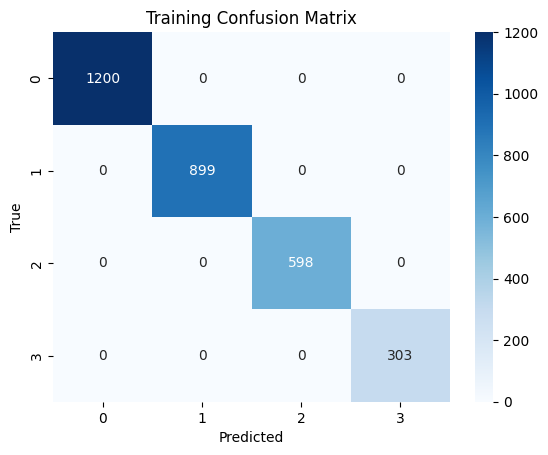

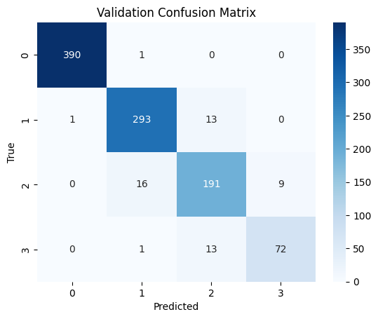

```python
# Visualize confusion matrixes
# Training CM

plt.figure
sns.heatmap(train_cm, annot=True, fmt='d', cmap='Blues')
plt.title('Training Confusion Matrix')
plt.xlabel('Predicted')
plt.ylabel('True')
plt.show()
print('\n')

# Validation CM

plt.figure
sns.heatmap(val_cm, annot=True, fmt='d', cmap='Blues')
plt.title('Validation Confusion Matrix')
plt.xlabel('Predicted')
plt.ylabel('True')
plt.show()
```

Given the public health context, false negatives are more costly. Underestimating the severity of air pollution creates a real health risk for vulnerable groups and the population as a whole.

## Model Selection

```python
# Tune hyperparamters to find the best model
# Define parameter grid

param_grid = {
    'classifier__n_estimators': [50, 100, 200],
    'classifier__max_depth': [None, 5, 10, 20],
    'classifier__max_features': ['sqrt', 'log2'],
    'classifier__min_samples_split': [2, 5, 10],
    'classifier__min_samples_leaf': [1, 2, 5],
    'classifier__bootstrap': [True, False],
    'classifier__class_weight': [None, 'balanced']
}


# Fit GridSearchCV to training data using 5-fold cross-validation

grid_search = GridSearchCV(pipeline, param_grid, cv=5, scoring='accuracy', n_jobs=-1, verbose=1)
grid_search.fit(X_train, y_train)
```

```
Fitting 5 folds for each of 864 candidates, totalling 4320 fits
```

```
GridSearchCV(cv=5,
             estimator=Pipeline(steps=[('scaler', StandardScaler()),
                                       ('classifier',
                                        RandomForestClassifier())]),
             n_jobs=-1,
             param_grid={'classifier__bootstrap': [True, False],
                         'classifier__class_weight': [None, 'balanced'],
                         'classifier__max_depth': [None, 5, 10, 20],
                         'classifier__max_features': ['sqrt', 'log2'],
                         'classifier__min_samples_leaf': [1, 2, 5],
                         'classifier__min_samples_split': [2, 5, 10],
                         'classifier__n_estimators': [50, 100, 200]},
             scoring='accuracy', verbose=1)
```

```python
# Get best model based on grid search

best_model = grid_search.best_estimator_


# Best paramters found & best cross-validation score

print(f"Best parameters found: {grid_search.best_params_}")
print(f"Best accuracy score: {grid_search.best_score_:.4f}")
```

```
Best parameters found: {'classifier__bootstrap': True, 'classifier__class_weight': 'balanced', 'classifier__max_depth': 10, 'classifier__max_features': 'sqrt', 'classifier__min_samples_leaf': 2, 'classifier__min_samples_split': 2, 'classifier__n_estimators': 200}
Best accuracy score: 0.9607
```

Using GridSearchCV, the parameters that produce the best accuracy score are:

- bootstrap=True
- class_weight='balanced'
- max_depth=10
- max_features='sqrt'
- min_samples_leaf=2
- min_samples_split=2
- n_estimators=200

These parameters will be added to the Random Forest classifier to train and test the final model.

# Feature Importance

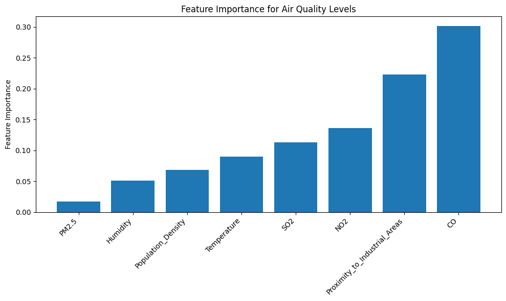

```python
# Get feature importance

feature_importances = best_model.named_steps['classifier'].feature_importances_
feature_names = X.columns

# Sort & visualize features by importance

sorted_idx = feature_importances.argsort()
plt.figure(figsize=(10, 6))
plt.bar(feature_names[sorted_idx], feature_importances[sorted_idx])
plt.ylabel('Feature Importance')
plt.title('Feature Importance for Air Quality Levels')
plt.xticks(rotation=45, ha='right')
plt.tight_layout()
plt.show()
```

**Observations:**

- Most important features for prediciting air quality: "CO", "Proximity_to_Industrial_Areas"
- Least important: "PM2.5", "Humidity"

# Final Performance on Test Set

```python
# Combine train & validatition set

X_train_final = pd.concat([X_train, X_val])
y_train_final = pd.concat([y_train, y_val])

# Get test set

X_test_final = X_test
y_test_final = y_test


# Train final model on combined train & val set

final_pipeline = Pipeline([
    ('scaler', StandardScaler()),
    ('classifier', RandomForestClassifier(bootstrap=True, class_weight='balanced', max_depth=10, max_features='sqrt', min_samples_leaf=2, min_samples_split=2, n_estimators=200)),
])

final_pipeline.fit(X_train_final, y_train_final)
```

```
Pipeline(steps=[('scaler', StandardScaler()),
                ('classifier',
                 RandomForestClassifier(class_weight='balanced', max_depth=10,
                                        min_samples_leaf=2,
                                        n_estimators=200))])
```

```python
# Evaluate on train set

y_train_pred = final_pipeline.predict(X_train_final)
train_accuracy = accuracy_score(y_train_final, y_train_pred)
train_cr = classification_report(y_train_final, y_train_pred)
train_cm = confusion_matrix(y_train_final, y_train_pred)

# Evaluate on test set

y_test_pred = final_pipeline.predict(X_test_final)
test_accuracy = accuracy_score(y_test_final, y_test_pred)
test_cr = classification_report(y_test_final, y_test_pred)
test_cm = confusion_matrix(y_test_final, y_test_pred)

print(f"Final Model Performance (Test Set):\n")
print(f"Training Accuracy: {train_accuracy}")
print(f"Training Classification Report: \n{train_cr}")
print(f"Training Confusion Matrix: \n{train_cm}\n")
print(f"Test Accuracy: {test_accuracy}")
print(f"Test Classification Report: \n{test_cr}")
print(f"Test Confusion Matrix: \n{test_cm}")
```

```
Final Model Performance (Test Set):

Training Accuracy: 0.985
Training Classification Report:
              precision    recall  f1-score   support

           0       1.00      1.00      1.00      1591
           1       0.98      0.99      0.98      1206
           2       0.96      0.97      0.96       814
           3       0.99      0.96      0.97       389

    accuracy                           0.98      4000
   macro avg       0.98      0.98      0.98      4000
weighted avg       0.99      0.98      0.98      4000

Training Confusion Matrix:
[[1590    1    0    0]
 [   0 1191   15    0]
 [   0   23  786    5]
 [   0    0   16  373]]

Test Accuracy: 0.957
Test Classification Report:
              precision    recall  f1-score   support

           0       1.00      1.00      1.00       409
           1       0.97      0.97      0.97       294
           2       0.87      0.90      0.89       186
           3       0.91      0.86      0.88       111

    accuracy                           0.96      1000
   macro avg       0.94      0.93      0.94      1000
weighted avg       0.96      0.96      0.96      1000

Test Confusion Matrix:
[[409   0   0   0]
 [  0 284  10   0]
 [  0   8 168  10]
 [  0   0  15  96]]
```

Model produces similar accuracies for the final train & test set (98.5% vs 95.7%). There is a small generalization gap (~2.8%), so the model is not overfitting the training data. 86% of hazardous air quality events are correctly detected, but there are no extreme misclassifications.

```python
# Calculate additional metrics (precision, recall, f1-score) for comparison

train_precision = precision_score(y_train_final, y_train_pred, average='macro')
train_recall = recall_score(y_train_final, y_train_pred, average='macro')
train_f1 = f1_score(y_train_final, y_train_pred, average='macro')

test_precision = precision_score(y_test_final, y_test_pred, average='macro')
test_recall = recall_score(y_test_final, y_test_pred, average='macro')
test_f1 = f1_score(y_test_final, y_test_pred, average='macro')

# Compare training vs test performance

comparison = pd.DataFrame({
    'Metric': ['Accuracy', 'Precision', 'Recall', 'F1-Score'],
    'Training': [train_accuracy, train_precision, train_recall, train_f1],
    'Test': [test_accuracy, test_precision, test_recall, test_f1],
})
print(comparison)
```

```
      Metric  Training      Test
0   Accuracy  0.985000  0.957000
1  Precision  0.982269  0.937182
2     Recall  0.977851  0.933519
3   F1-Score  0.980006  0.935155
```

**Performance Summary:**

- Overall, the model performs well: 95.7% test accuracy & no overfitting
- Performance is balanced across all classes with similar precision, recall, & F1-scores for train & test sets
- Some underprediction for "Poor" and "Hazardous" classes; may require additional paramter tuning
- Most important features: "CO", "Proximity_to_Industrial_Areas"

# Ethical Concerns & Model Limitations

**Ethical Concerns**

- Public health risk from false negatives (hazardous air quality) can lead to preventable health consequences for vulnerable populations.
- Mispredictions could delay public health interventions with overreliance on automated decision-making; must also consider human insight and monitoring systems when assessing air quality.

**Data & Model Limitations**

- Dataset is imbalanced; class weighting does beenfit model performance, adding samples to minority classes ("Poor" & "Hazardous") could improve recall.
- Misclassification between neighboring air quality levels could affect timing and magnitiude of public health warnings for unhealthy air levels.